# Civilian Drone Strike Murders have Increased as Years Have Gone On, Independent of Drone Strike Counts: Exploring the Data Science Pipeline Through Confirmed US Drone Strikes in Afghanistan, Pakistan,

### The Bureau of Investigative Journalism's 2010-2020 Drone Warfare Project's Data Collection

Between 2010 and 2020, The Bureau of Investigative Journalism (TBIJ) "tracked US drone strikes and other covert actions in Pakistan, Afghanistan, Yemen and Somalia." To this end, they [used](https://www.thebureauinvestigates.com/explainers/our-methodology) "thousands of press reports filed by reputable national and international media outlets," data provided by NATO and other US-led or US sources, three field investigations, legal cases, leaked information and more to compile its data over the lifetime of the project.

### Limitations of the "Drone Warefare" dataset

The Bureau of Investigative Journalism (TBIJ)'s variety of sources alongside the US' interests in keeping strategic and tactical information secret and civilian death's undercounted means that TBIJ's results are necessarily incomplete.

Furthermore, TBIJ points out that there can be contradictory information reported about the number of deaths. While they updated their counts as new information was released, this results in a reported range wherein the minimum remains the same and the maximum number changes to include new potential information.

It is also notable that each country's respective datasets differ with regards to time frame, data collected, and data availability. This is reflected in both the number of observations, and the number of possible values.

Despite these limitations, TBIJ remains an exceedingly comprehensive source for information on US drone strike in Afghanistan, Pakistan, Yemen, and Somalia from 2010-2020.

### Other forms of data collection

Not all data will exist in a Google Sheets page. We saw above how we could use the `pandas.read_csv` function to extract CSV from a URL to a `DataFrame`. We could also store a CSV locally, and access it using the same `pandas.read_csv` function, but with its file path instead of the URL.

`pandas` provides a number of methods similar to that lets one read formatted information directly into a `DataFrame`. There is a good chance that if you have some common formated data, `pandas` has a method to allow you to collect it into a DataFrame. Be sure to read the `pandas` [documentation](https://pandas.pydata.org/pandas-docs/stable/reference/index.html) for a full list and explanation of methods allowing one to read [an Excel file](https://pandas.pydata.org/pandas-docs/stable/reference/api/pandas.read_excel.html#pandas.read_excel), [SQL tables](https://pandas.pydata.org/pandas-docs/stable/reference/api/pandas.read_sql.html), [JSON](https://pandas.pydata.org/pandas-docs/stable/reference/api/pandas.read_json.html#pandas.read_json) formated data and more into a `pandas.DataFrame`s.

Another way to access an existing dataset is through a website's **API**. An API (Application Programming Interface) allows you to ask a server for information they already have stored in a database. If the request (or "query") is in a valid form with the necessary credentials, then it should return the information asked for in a structured document. You can frequently access APIs through python's `requests` module. [This module](https://docs.python-requests.org/en/latest/) allows one to make HTTP requests. One common form of API is a [REST API](https://realpython.com/api-integration-in-python/).

Unfortunately, many websites do not have APIs, or APIs that have all the information that you want to get. If you still need to get a dataset from a website in these cases, you may need to "scrape" the information from the HTML and/or CSS on the page. This process is called web scrapping. `BeautifulSoup` is package commonly used for scraping and parsing HTML data. It's documentation can be found [here](https://www.crummy.com/software/BeautifulSoup/bs4/doc/). You can find out more information about web-scrapping [here](https://www.scrapingbee.com/blog/web-scraping-101-with-python/#3-requests--beautifulsoup).

## 2. Data Management - Getting our collected "Drone Warfare" data in a useable form

We've already begun managing our "Drone Warfare" dataset by importing them into `pandas.DataFrame`s. But, at this point, each country's dataset are separate attributes of their respective **Drone_Data** object. It might be good to keep their separate `pandas.DataFrame`s for later.

We want to begin by looking for trends, or clues to dig into across the whole dataset. This is called the "Exploratory data Analysis" part of the pipeline (more on that later). Before we can do this sort of broad analysis, however, we'll want to combine all of our data in one `pandas.DataFrame`.

We could naively combine each conutry's `Drone_Data.df`. But it's important to **be familiar with your dataset** before we begin managing it. Familiarizing oneself with the dataset can help guide analytic decisions, avoid unncessary pitfalls, and make choices with managing the dataset.

Let's begin by taking a look at what kind of overlap we already have:

```python
# A pandas.DataFrame has a columns method which will return a series containing
# all of the column labels. We can then use the python .intersection(...) method to
# find the overlapping values between two such series.
# Since .intersection(...) returns a list, we can call an .intersection(...) on
# the result of the first call while passing in a new country's column series,
# and so on for all of the countries to find the columns that intersect all four
# of our dataframes.
shared_columns = afghanistan_strikes.df.columns.intersection(yemen_strikes.df.columns) \
                    .intersection(pakistan_strikes.df.columns) \
                    .intersection(somalia_strikes.df.columns)

shared_columns
```

```
Index(['Date', 'Strike link'], dtype='object')
```

So if we take the data as given to us, only the **Date** and **Strike link** columns are shared between each country's DataFrame.

First, we will convert the Date column from a string to a datetime object. This allows for easier manipulation of the date.

We will also go ahead and extract the year from this object into its own column. This is so that we can use it as a "bucket value" later on. A "bucket value," or "bin" refers to a group of data that share some characteristic. Binning information can be useful when there is a "noisy" continuous variable, like month and day for change over time. If you're more interested in binning, check out [this](https://stackoverflow.com/questions/65472200/when-should-data-binning-be-used-in-data-processing#:~:text=Binning%20would%20be%20wise%20to,binning%20or%20equal%20frequency%20binning.) StackOverflow answer.

```python
for country in country_list:
    # You can provide a format for the to_datetime function
    # Note that our Date takes a non-American style of datetime
    country.df['Date'] = pd.to_datetime(country.df['Date'], format="%d/%m/%Y")
    country.df['Year'] = country.df['Date'].dt.year
```

But when we eyeball the column labels on their respective Google Sheets pages, we can see that there are many columns that are reporting the same kind of data but have slightly different labels.

Let's rename these aberant columns labels to be the same across all of our `pandas.DataFrame`s so it will be easier to later combine their respective data into one `pandas.DataFrame`:

```python
# Note: the inplace keyword means that we will adjust the existant DataFrame.
# If we didn't use it, we'd have to assign this version of the DataFrame
# to a new DataFrame, or our renaming wouldn't persist.
# This is a useful keyword across many pandas function.
# But be careful not to overwrite a DataFrame that has data you want to keep
# with it!
somalia_strikes.df.rename(columns = {'Unnamed: 0':'Strike ID',
                                     'Minimum people killed':'Minimum total people killed',
                                     'Maximum people killed':'Maximum total people killed',
                                     'Minimum civilians killed':'Minimum civilians reported killed',
                                     'Maximum civilians killed':'Maximum civilians reported killed',
                                     'Minimum children killed':'Minimum children reported killed',
                                     'Maximum children killed':'Maximum children reported killed',
                                     'Minimum people injured':'Minimum reported injured',
                                     'Maximum people injured':'Maximum reported injured'},
                                      inplace = True)

yemen_strikes.df.rename(columns = {'Minimum people killed':'Minimum total people killed',
                                   'Maximum people killed':'Maximum total people killed',
                                   'Minimum people injured':'Minimum reported injured',
                                   'Maximum people injured':'Maximum reported injured'},
                                    inplace = True)
```

Note that each DataFrame has different ways of representing the strikes location with different levels of detail in the data collected. Furthermore, each of these countries have different ways of organizing regions administratively.

```python
afghanistan_strikes.df['overall_location'] = afghanistan_strikes.df['Village/local area'] + ',' \
                                            + afghanistan_strikes.df['District'] + ','\
                                            + afghanistan_strikes.df['Province']
pakistan_strikes.df['overall_location'] = pakistan_strikes.df['Location'] + ',' \
                                        + pakistan_strikes.df['Area']
yemen_strikes.df['overall_location'] = yemen_strikes.df['Location'] + ',' \
                                        + yemen_strikes.df['Province']
somalia_strikes.df.rename(columns = {'Location' : 'overall_location'}, inplace = True)
```

We can also note that 'Type of attack' exists as a column in `afghanistan_strikes.df` and `yemen_strikes.df`. There are quite different types of values in the two DataFrames. In `afghanistan_strikes.df`'s 'Type of attack' conveys the origin of the attack (from the US, from Nato, etc), while `yemen_strikes.df`'s 'Type of attack' tells the military platform a strike was carried out on. This is similar to `yemen_strikes.df`'s 'Strike type', though it has less detail.

We'll rename the yemen_strikes `yemen_strikes.df`'s 'Type of attack' to 'Strike type' to better reflect this.

```python
yemen_strikes.df.rename(columns = {'Type of attack' : 'Strike type'}, inplace = True)
```

Let's recheck our columns to see how they match-up after these renamings:

```python
shared_columns = afghanistan_strikes.df.columns.intersection(yemen_strikes.df.columns)\
                    .intersection(pakistan_strikes.df.columns)\
                    .intersection(somalia_strikes.df.columns)

shared_columns
```

```
Index(['Strike ID', 'Date', 'Minimum total people killed',
       'Maximum total people killed', 'Minimum civilians reported killed',
       'Maximum civilians reported killed', 'Minimum children reported killed',
       'Maximum children reported killed', 'Minimum reported injured',
       'Maximum reported injured', 'Strike link', 'Year', 'overall_location'],
      dtype='object')
```

Now that we've standardized our shared column names we can combine our `DataFrame`s into one.

```python
# Create a new DataFrame to store our combined data in
all_countries_strikes_df = pd.DataFrame()

# Variable used to track total length of original DataFrames
total_df_len = 0

# For each of our countries, we will add the length of it to total_df_len for a later confirmation
# Then, we will concat these values to the all_countries_strikes_df DataFrame. Concat allows us to
# combine DataFrames.
# We are choosing the axis=0 keyword so that we are combining our rows, and the
# ignore_index=True keyword so that we do not align the columns on the rows we already have in DataFrame.
# Note that we are using the .reset_index() method on our second concatinated term to ensure that our index
# is numerical and can thusly be added to all_countries_strikes_df consistently.
for country in country_list:
    total_df_len += len(country.df.index)
    all_countries_strikes_df = pd.concat([all_countries_strikes_df, country.df.reset_index()],
                                         axis=0, ignore_index=True)
```

Let's do a quick sanity check on this master DataFrame to ensure that we didn't accidently drop any rows in our concatination. To this end, we'll compare the sum of all of the individual dataframe's lengths to the total DataFrame's length to accomplish this.

As a data scientist, **small checks small sanity checks like this throughout your code can help you catch issues as they arise**. For instance, if we were to need to do [SQL style merges](https://pandas.pydata.org/docs/reference/api/pandas.DataFrame.merge.html) to combine data frames, it could have been very easy to accidentally drop columns or rows--especially for complicated merges.

```python
total_df_len == len(all_countries_strikes_df.index)
```

```
True
```

It looks like all of our data migrated over to the `all_countries_strikes_df` DataFrame. Let's take at it's columns to determine if there is anything we can do to make it more useable:

```python
all_countries_strikes_df.columns
```

```
Index(['index', 'Strike ID', 'Date', 'Village/local area', 'District',
       'Province', 'Type of attack', 'Reportedly drone?', 'US confirmed?',
       'US only source?',
       'Counter-\nterrorism, force protection or strategic effects?',
       'Reported target group?', 'Time', 'Reported target type',
       'Minimum strikes', 'Maximum strikes', 'Minimum total people killed',
       'Maximum total people killed', 'Minimum civilians reported killed',
       'Maximum civilians reported killed', 'Minimum children reported killed',
       'Maximum children reported killed', 'Minimum reported injured',
       'Maximum reported injured', 'Strike link', 'Timeline URL', 'Index',
       'Year', 'overall_location', 'Location', 'Strike type',
       'Confirmed/\npossible US attack?', 'Air operation?', 'Drone strike',
       'Minimum number of strikes', 'Maximum number of strikes', 'Unnamed: 19',
       'Area', 'Unnamed: 13', 'Confirmed/\npossible US strike', 'Air strike?',
       'Unnamed: 18'],
      dtype='object')
```

### Dialectics of Data Science: Returning to previous steps in the pipeline

There are a three columns titled **Unnamed: x**, with different integer values in "x". It's not very clear what they are from looking at our DataFrame alone. So we'll need take a look at the original data again.

This **dialectic movement between data collection and data management** is an important part of the data science pipeline. As we comb through our data, we may have questions that our data alone cannot answer. We often need to add context, and sometimes even need to **collect more data**. This dialectical movement occurs throughout the pipeline. In this sense, **"pipeline" is perhaps a flawed metaphor for trying to answer a question using data science**. It implies that we are only moving in one direction, like water flowing down, or up a pipe. Instead, it's more like a set of data science "see saws" wherein movement in one part of the process will influence movement needed for another part.

In your own data science work, it is important to recognize, at each step (i.e. not just the data management step) when to look at previous steps and see how returning to them can help strengthen your work.

With this in mind, when we look at how **Unnamed: x** is used in the original datasets on Google Sheets, we'll note that for the Afghanistan, and Pakistan Drone Warfare data they refer to an "index" value internal to The Bureau of Investigative Journalism (TBIJ). There is not an unnamed column in the Somalia data set. Finally, the Yemen data set's "Unnamed: x" contains an occational dead link to a TBIJ article.

Since we are not interested in doing data science on TBIJ's coverage of these articles, the data stored in these columns is largely vestigial. We can drop their respective columns:

```python
# Note that you can pass in a list like set into the drop function,
# we are specifying that we want specific columns dropped with the columns keyword
all_countries_strikes_df.drop(columns=["Unnamed: 19", "Unnamed: 18", "Unnamed: 13"], inplace=True)
```

### Tidying Data

Another way in which we can manage our data is through **Tidy Data**. Hadley Wickham defines [tidying data](https://cmsc320.github.io/files/tidy_data.pdf) as "structuring datasets to facilitate analysis." According to Wickham, tidy data must pertain to a specific structure: "each variable is a column, each observation is a row, and each type of observational unit is a table."

If the ultimate goal of tidying is to "facilitate analysis" **you should consider the usefulness of tidying for your specific data set**. For instance, our "Drone Warfare" data is a bit strange with regards to tidying. Let's take a look:

#### Tidying 1: "Each variable is a column"

If each variable is a column then we have several columns that may be combined. For instance, any of the columns that have "minimum" and "maximums" prefixes could be combined to represent a range.

However, there is an argument made that these are distinct variables. Once again, we should return to our original dataset to help make our decision. [According to](https://www.thebureauinvestigates.com/explainers/our-methodology) The Bureau of Investigative Journalism (TBIJ) "credible sources differ over how many people were killed we provide a minimum and maximum count of the number of people reported killed." Elsewhere, the TBIJ methodology page notes the minimum numbers are "unchanged," while the maximum was updated over time. This means that each "maximum" prefix is actually the composite of a variable number of observations.

So, because there are different methods used to collect "minimum" and "maximum" data in the original set, I believe they should be considered different variables.

#### Tidying 2: "Each observation is a row"

Furthermore, we know that the ranges can't be segregated into equal sized bins because the maximum is uncertain. So it's possible that a value like the SOM003 strike on 09/01/2007 in Somalia which killed at least 4 people, but as many as 31 could fit in a variety of bins.

Thus, we don't have any great way of "tidying" our data with regards to the rows.

**Melting DataFrames**

Sometimes, observations are presented as columns. This results in what is called a "wide" table. If you want to make a wide `pandas.DataFrame` tidy, you can use the [pandas.melt](https://pandas.pydata.org/docs/reference/api/pandas.melt.html) function. Users of `pandas.melt` will pass the method a DataFrame, and then identify a set of "one or more columns are identifier variables (`id_vars`)." These `id_vars` are kept as columns. The rest of the columns are known as measured variables (`value_vars`). [Here's](http://shzhangji.com/blog/2017/09/30/pandas-and-tidy-data/) a useful for guide for using the melt function if you need to use it.

These `value_vars` columns are "unpivoted" by `pandas.melt` to become rows. The pivoted `value_vars` will retain whatever their original `id_vars` are in their new row.

Once a "wide" table is melted into a "long" table (also known as a "molten" table), it can be further manipulated into making each variable a column if necessary.

#### Tidying 3: "Each type of observational unit is a table"

This is a principle of Tidy Data that we can apply to our dataset! Specifically, we have a clear "death" observational type. This will include the following set of columns:

```python
death_columns = ['Minimum total people killed', 'Maximum total people killed',
                 'Minimum civilians reported killed', 'Maximum civilians reported killed',
                 'Minimum children reported killed', 'Maximum children reported killed']

# We can select subsets of DataFrames using dataframe_name[[list_of_columns]]
# We'll include the the "Strike ID" as a key value between different DataFrames
death_df = all_countries_strikes_df[["Strike ID"] + death_columns]
```

Another common observational type is "location". We have several location columns that we can combine in a DataFrame.

```python
location_columns = ['overall_location', 'Village/local area', 'District', 'Province', 'Location', 'Area']
location_df = all_countries_strikes_df[["Strike ID"] + location_columns]
```

## 3. Exploratory Analysis - What can we figure out by looking at our managed data

So we've selected a data source, downloaded it, and managed our data to be in a usable form. Now what?

It can be difficult to decide what to look for in a dataset. Exploratory analysis can help us get a "feel" for the data set. We can use summary statistics (like mean, standard, deviation, sums, etc.) and visualizations to identify trends, problems, skew, and other relations that are imminent in our dataset.

We can use such relationships to form a hypothesis around. This hypothesis will lead us into Hypothesis testing. But, because our **data is dialectic** we may decided that we need to manage our data in a different way to learn more, returning to step 2, or that we need to collect more data, returning to step 1.

We'll begin by looking at some summary statistics for our dataset:

### Summary statistics - descriptive statistics

We can use summary statistics to describe sets of data in simpler terms. This is a part of **descriptive statistics**. The `pandas.DataFrame.describe()` give such statistics for a given DataFrame or Dataframe column. According to the [documentation](https://pandas.pydata.org/docs/reference/api/pandas.DataFrame.describe.html) these statistics include: "count, mean, std, [min](https://pandas.pydata.org/docs/reference/api/pandas.DataFrame.min.html), [max](https://pandas.pydata.org/docs/reference/api/pandas.DataFrame.max.html) as well as lower, [[median](https://pandas.pydata.org/docs/reference/api/pandas.DataFrame.median.html)] and upper percentiles. By default the lower percentile is 25 and the upper percentile is 75. The 50 percentile is the same as the median."

We need to call `describe()` on a column that has numerical data for to return summary statistics. This seems to fit the "death" information contained in our `death_df` DataFrame which looks at all of our countries.

```python
death_df.describe()
```

|  | Minimum total people killed | Maximum total people killed | Minimum civilians reported killed | Maximum civilians reported killed | Minimum children reported killed | Maximum children reported killed |
| --- | --- | --- | --- | --- | --- | --- |
| count | 5184.000000 | 5184.000000 | 5184.000000 | 5184.000000 | 5184.000000 | 5184.000000 |
| mean | 1.816744 | 3.433642 | 0.188465 | 0.443673 | 0.062886 | 0.092593 |
| std | 6.521990 | 9.552289 | 1.881953 | 2.947595 | 1.138279 | 1.246996 |
| min | 0.000000 | 0.000000 | 0.000000 | 0.000000 | 0.000000 | 0.000000 |
| 25% | 0.000000 | 0.000000 | 0.000000 | 0.000000 | 0.000000 | 0.000000 |
| 50% | 0.000000 | 0.000000 | 0.000000 | 0.000000 | 0.000000 | 0.000000 |
| 75% | 0.000000 | 4.000000 | 0.000000 | 0.000000 | 0.000000 | 0.000000 |
| max | 220.000000 | 220.000000 | 80.000000 | 82.000000 | 68.000000 | 70.000000 |

We'll note that the inter-quartile range provided by the `describe()` function is heavily dominated by the number of zeros, indicating deaths only existing in the top 25% of data. We would expect to see similar trends in each of the countries.

Let's check:

```python
print(afghanistan_strikes.name + " Summary Stats: \n")
afghanistan_strikes.df[death_columns].describe()
```

```
Afghanistan Summary Stats:
```

|  | Minimum total people killed | Maximum total people killed | Minimum civilians reported killed | Maximum civilians reported killed | Minimum children reported killed | Maximum children reported killed |
| --- | --- | --- | --- | --- | --- | --- |
| count | 4238.000000 | 4238.000000 | 4238.000000 | 4238.000000 | 4238.000000 | 4238.000000 |
| mean | 0.978764 | 2.388627 | 0.077867 | 0.207173 | 0.024068 | 0.046720 |
| std | 5.466574 | 8.812779 | 1.135426 | 2.169918 | 0.507565 | 0.667664 |
| min | 0.000000 | 0.000000 | 0.000000 | 0.000000 | 0.000000 | 0.000000 |
| 25% | 0.000000 | 0.000000 | 0.000000 | 0.000000 | 0.000000 | 0.000000 |
| 50% | 0.000000 | 0.000000 | 0.000000 | 0.000000 | 0.000000 | 0.000000 |
| 75% | 0.000000 | 0.000000 | 0.000000 | 0.000000 | 0.000000 | 0.000000 |
| max | 220.000000 | 220.000000 | 42.000000 | 64.000000 | 20.000000 | 20.000000 |

```python
print(pakistan_strikes.name + " Summary Stats: \n")
pakistan_strikes.df[death_columns].describe()
```

```
Pakistan Summary Stats:
```

|  | Minimum total people killed | Maximum total people killed | Minimum civilians reported killed | Maximum civilians reported killed | Minimum children reported killed | Maximum children reported killed |
| --- | --- | --- | --- | --- | --- | --- |
| count | 430.000000 | 430.000000 | 430.000000 | 430.000000 | 430.000000 | 430.000000 |
| mean | 5.848837 | 9.362791 | 0.986047 | 2.253488 | 0.400000 | 0.481395 |
| std | 6.575928 | 8.323221 | 4.433375 | 6.184304 | 3.410255 | 3.550945 |
| min | 0.000000 | 0.000000 | 0.000000 | 0.000000 | 0.000000 | 0.000000 |
| 25% | 3.000000 | 5.000000 | 0.000000 | 0.000000 | 0.000000 | 0.000000 |
| 50% | 4.000000 | 7.000000 | 0.000000 | 0.000000 | 0.000000 | 0.000000 |
| 75% | 6.000000 | 11.000000 | 0.000000 | 3.000000 | 0.000000 | 0.000000 |
| max | 81.000000 | 83.000000 | 80.000000 | 82.000000 | 68.000000 | 70.000000 |

```python
print(yemen_strikes.name + " Summary Stats: \n")
yemen_strikes.df[death_columns].describe()
```

```
Yemen Summary Stats:
```

|  | Minimum total people killed | Maximum total people killed | Minimum civilians reported killed | Maximum civilians reported killed | Minimum children reported killed | Maximum children reported killed |
| --- | --- | --- | --- | --- | --- | --- |
| count | 326.000000 | 326.000000 | 326.000000 | 326.000000 | 326.000000 | 326.000000 |
| mean | 4.641104 | 6.478528 | 0.634969 | 0.996933 | 0.156442 | 0.187117 |
| std | 6.768936 | 8.545147 | 3.514174 | 4.086374 | 1.330149 | 1.407219 |
| min | 0.000000 | 0.000000 | 0.000000 | 0.000000 | 0.000000 | 0.000000 |
| 25% | 2.000000 | 2.250000 | 0.000000 | 0.000000 | 0.000000 | 0.000000 |
| 50% | 3.000000 | 4.000000 | 0.000000 | 0.000000 | 0.000000 | 0.000000 |
| 75% | 5.000000 | 7.000000 | 0.000000 | 0.000000 | 0.000000 | 0.000000 |
| max | 55.000000 | 71.000000 | 44.000000 | 44.000000 | 21.000000 | 22.000000 |

```python
print(somalia_strikes.name + " Summary Stats: \n")
somalia_strikes.df[death_columns].describe()
```

```
Somalia Summary Stats:
```

|  | Minimum total people killed | Maximum total people killed | Minimum civilians reported killed | Maximum civilians reported killed | Minimum children reported killed | Maximum children reported killed |
| --- | --- | --- | --- | --- | --- | --- |
| count | 190.000000 | 190.00000 | 190.000000 | 190.000000 | 190.000000 | 190.000000 |
| mean | 6.536842 | 8.10000 | 0.084211 | 0.673684 | 0.005263 | 0.073684 |
| std | 15.189672 | 18.33075 | 0.547494 | 2.809440 | 0.072548 | 0.465579 |
| min | 0.000000 | 0.00000 | 0.000000 | 0.000000 | 0.000000 | 0.000000 |
| 25% | 1.000000 | 1.00000 | 0.000000 | 0.000000 | 0.000000 | 0.000000 |
| 50% | 2.500000 | 3.00000 | 0.000000 | 0.000000 | 0.000000 | 0.000000 |
| 75% | 6.000000 | 8.00000 | 0.000000 | 0.000000 | 0.000000 | 0.000000 |
| max | 150.000000 | 200.00000 | 5.000000 | 31.000000 | 1.000000 | 5.000000 |

Comparing the count can help contectualize this:

```python
# Since we know from above that every country has
# entries for the all of the death_columns, we only need to look at
# one representative column to determine the proportion from each country
country_proportions = {}

for country in country_list:
    country_proportions[country.name] = country.df[death_columns[0]].count()/death_df[death_columns[0]].count()

print(country_proportions)
```

```
{'Afghanistan': 0.8175154320987654, 'Yemen': 0.0628858024691358, 'Pakistan': 0.08294753086419752, 'Somalia': 0.03665123456790124}
```

This is a great example of **the power of exploratory data analysis using summary statistics**. We can "eyeball" the data and recognize that Afghanistan's drone warfare data is a much larger percentage of the overall dataset than the other country's. But without look at what those percentages actually are, side-by-side, it's entirely unclear how much more impactful Afghanistan is on the overall spread of the data.

With this is mind, we can already dialectically return to our data management step and make a fairly significant choice: since there's so much more reported drone activity in Afghanistan we will make sure to differentiate our analysis across countries rather than focus on collective data sets.

As we can see from this exploratory analysis, the size Afghanistan Drone Warfare dataset will have an unsized impact on any other country if they are naively included together in an undifferentiated manner in a data set.

This is a great example of the dialectical nature of the data science "pipeline," or as we called it earlier, "see saws." **Once you learn more information from one step, you should look at previous steps to see how changes in them can strengthen your analysis**.

Now that we know we're focusing on each country's subset, we can adjust the focus of our analysis specifically on these set rather than the larger sets.

### Summary statistics - correlative description

Another form of summary statistics you can use in your exploratory analysis are **correlative descriptions**. Correlative descriptions allow us to compare two variables and seek trends between them. **Correlation** refers to when two variables, we'll call them $X$ and $Y$ vary together.

But, as the famous saying goes "correlation does not equal causation." This means that correlation may reveal some sort of significant movement through a statistical relationship between $X$ and $Y$. But it also could mean that this is a "third term" that isn't considered that cause similar movement in $X$ and $Y$, while your $X$ and $Y$ are not actually reflecting one another. This third term influencing $X$ and $Y$ may also be called a **confounding variable**.

As such, **its important to consider how strong of claims you can make surrounding correlative descriptions**.

For our Drone Warfare dataset, we'll begin by comparing time to each country's respective "Minimum total people killed" and "Maximum total people killed" columns.

### Visualization

Visualization can be a powerful tool for gaining exploratory insights, especially with correlation in mind.

There are several visualization packages that may be of interest to you in your own data science work. Two of the most popular include [matplotlib](https://matplotlib.org/) and [seaborn](https://seaborn.pydata.org/). `pandas` itself also has some [built-in visualization methods](https://pandas.pydata.org/pandas-docs/version/0.25.0/reference/api/pandas.DataFrame.plot.scatter.html).

Let's use both covariance and a `pandas` scatter plot to visualize each country's "Minimum total people killed" and "Maximum total people killed" over time:

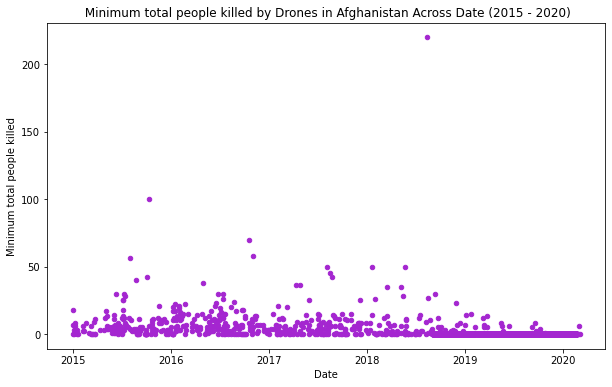

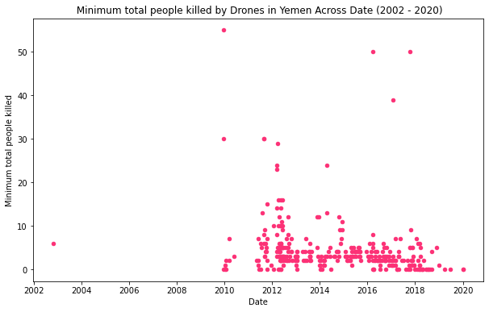

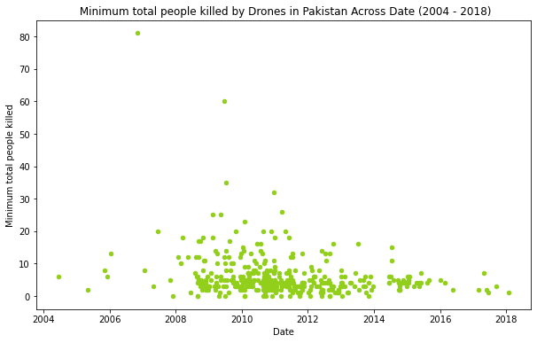

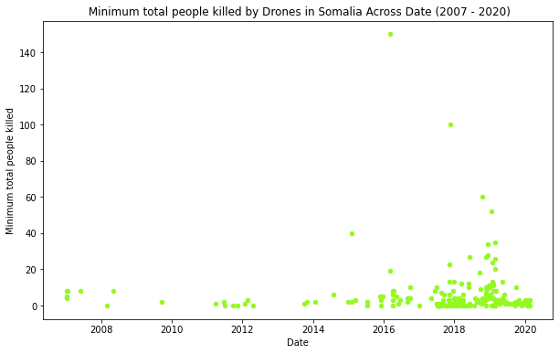

```python
for country in country_list:
    # Generate random color for data
    rgb = np.random.rand(3,)

    # Build the scatter plot
    # Set figsize parameter to larger size for legibility
    ax = country.df.plot.scatter(x="Date", y="Minimum total people killed", color=[rgb], figsize=(10, 6))

    # Label axes and title plot
    ax.set_xlabel("Date")
    ax.set_ylabel("Minimum total people killed")
    ax.set_title(f" Minimum total people killed by Drones in {country.name} " + \
                    f"Across Date ({min(country.df['Year'])} - {max(country.df['Year'])})")
```

Perhaps most striking about these graphs are the number of entries that seem to be around zero. This is in part, however, due to the TBIJ's reporting methodology wherein the "minimum" numbers they report are based on confirmed deaths. So they can be artifically low because of US security interests, and the limitations of local reporting mechanisms discussed above.

These scatterplots are also helpful in recognizing the spread of attacks over time. For instance, we can recognize that drone strikes had a larger spread of minimum killed people in Afghanistan between 2016 and 2017, in Yemen between 2012 and 2013, in Pakistan between 2009 and 2012, and in Somalia between 2018 and 2020. Another notable trend is the consistency of drone strikes reported across the entirity of the reported timeframe for Afghanistan vs. the notable gaps in the other countries in our data set.

But you also must be careful about allowing data visualizations to obscure data. For instance, the density of these points make it such that it can be difficult to differentiate between them.

Let's represent our data in a different way to see if we can garner any new insights. To this end a violin plot may be useful. A violin plot is a similar to a box-and-whisker plot, which plots the inner-quartile range, max and min of a graph, but it also rotated kernel density plot on each side. You can learn more about them [here](https://en.wikipedia.org/wiki/Violin_plot).

For our purposes a violin plot can help us determine the density of our data around certain "Minimum total people killed" data points. For our tutorial's sake will use `Seaborn` to make this plot to show you how to create plots with a different plotting library. But [matplotlib](https://www.tutorialspoint.com/matplotlib/matplotlib_violin_plot.htm#:~:text=Violin%20plots%20are%20similar%20to,in%20the%20standard%20box%20plots.) can also be used to make violin plots, if you prefer it or are familiar with matlab.

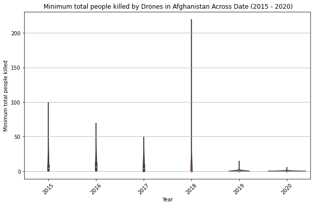

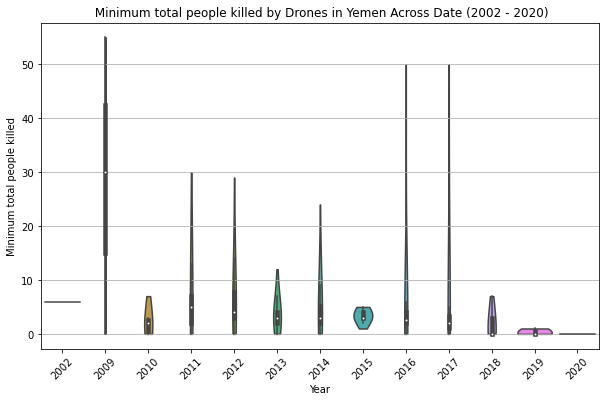

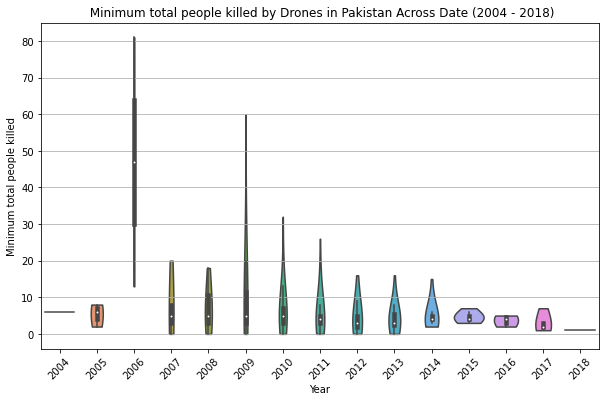

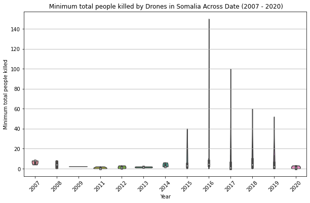

```python
for country in country_list:
    # Create Seaborn Plot object
    # Set figure size to a larger format for legibility
    fig, axes = plt.subplots(figsize=(10, 6))

    # Fill in Seaborn data
    # bw refers to bandwidth, we increased it for legibility
    # cut helps us work with a failure in Seaborn's Kernel density estimation
    # Seaborn assumes that "the underlying distribution is smooth and unbounded"
    # But we know that our graph is bounded by 0 because there cannot be less than zero deaths
    # Thus, we will use the cut parameter to adjust the cut off
    sns.violinplot(x='Year', y='Minimum total people killed', data=country.df, ax = axes, bw=1.5, cut=0)

    # Set title, labels, and y-axis grid
    axes.set_title(f" Minimum total people killed by Drones in {country.name} " + \
                        f"Across Date ({min(country.df['Year'])} - {max(country.df['Year'])})")
    axes.set_xlabel('Year')
    axes.set_ylabel('Minimum total people killed')
    axes.yaxis.grid(True)

    # Angle x-labels so they are legible
    plt.xticks(rotation=45)

    plt.show()
```

These plots confirm our suspisions about the density of our datasets that trend lower. It seems like there are some interesting outliers, such as Pakistan in 2006 wherein the lower end looks to be around 12 and the median seems to be around 47, or massive minimums like Somalia in 2016 at beyond 145, or Afghanistan in 220. These same outliers can be seen in the scatter plots as well.

We can continue to explore to check to see if we can notice any trends over the collected years through covariance.

### Covariance

Covariance between $X$ and $Y$ is represented by the formula:

$$cov(x,y) = \frac{1}{n} \sum^{n}_{i=1}(x_i-\bar{x})(y_i-\bar{y})$$

In this formula $n$ refers to the number of entries, $\bar{x}$ and $\bar{y}$ refer to the respective means of $x$ and $y$. We can note that a positive correlation, or a correlation wherein $X$ and $Y$ increase in the same direction as one another is reflected by a positive $cov(x,y)$. In contrast, a negative correlation, or a correlation wherein $X$ and $Y$ increase in opposite directions as one another is reflected by a negative $cov(x,y)$. This also implies that a $cov(x,y)$ near $0$ means that there is no strong relationship between $X$ and $Y$.

In `pandas` covariance is [pandas.DataFrame.cov](https://pandas.pydata.org/docs/reference/api/pandas.DataFrame.cov.html) function.

```python
for country in country_list:
    # Find and print covariance
    print(f"{country.name} Covariance of Year and Minimum total people killed: " +
          country.df["Year"].cov(country.df["Minimum total people killed"]).astype(str))
```

```
Afghanistan Covariance of Year and Minimum total people killed: -2.1040615811426857
Yemen Covariance of Year and Minimum total people killed: -3.6522416234072708
Pakistan Covariance of Year and Minimum total people killed: -3.087277064021248
Somalia Covariance of Year and Minimum total people killed: 0.37744360902255497
```

This set of covariances between "Year" and "Minimum total people killed" is interesting because there are seeming decreases in deaths over time for Afghanistan, Yemen, and Pakistan, while Somalia seems to have, relatively, stayed the same. But how can we be certain that these decreases are not just "noise."

One potential confounding variable for the decrease of over time is TBIJ logistical scaling down as the project wound down to a close. This means that TBIJ likely had fewer resources to collect from their vast network of different types of sources, especially field reports. However, Somalia's steady rate during this time remainings an interesting insight.

We haven't compared any means between datasets, so it is less important to standardize our data than it may be otherwise. But if you are comparing datasets more explicitly, then you may want to look into [this resource](https://www.sisense.com/glossary/data-standardization/).

I'm personally interesting in determining if there are any trends that can relate citizen deaths to time. Has the US gotten better at "not targetting civilians" as our imperialist ventures in the greater Middle East have continued?

Let's compare what I will call the "Civilian Death Differential" to year. The "Civilian Death Differential" is the ("Maximum civilians reported killed" - "Minimum civilians reported killed"). Let's repeat our analysis above.

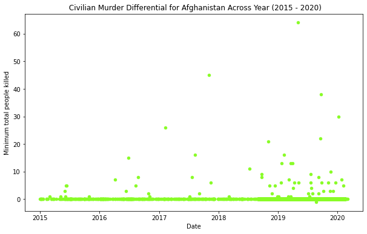

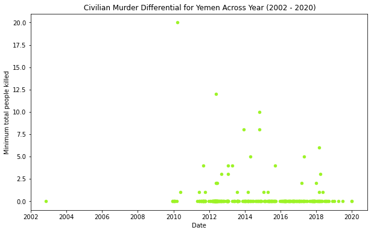

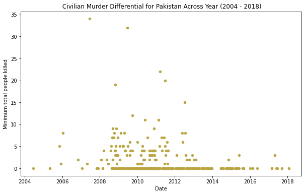

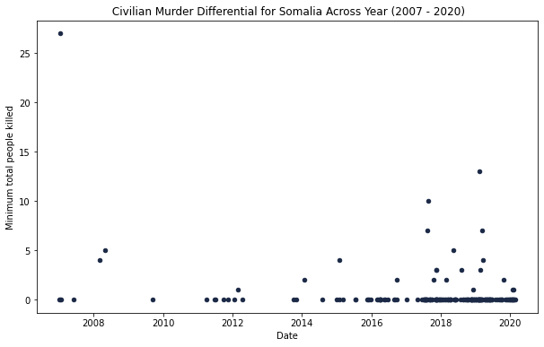

```python
for country in country_list:
    country.df["Civilian Murder Differential"] = \
        country.df["Maximum civilians reported killed"] - country.df["Minimum civilians reported killed"]

    # Generate random color for data
    rgb = np.random.rand(3,)

    # Build the scatter plot
    # Set figsize parameter to larger size for legibility
    ax = country.df.plot.scatter(x="Date", y="Civilian Murder Differential", color=[rgb], figsize=(10, 6))

    # Label axes and title plot
    ax.set_xlabel("Date")
    ax.set_ylabel("Minimum total people killed")
    ax.set_title(f" Civilian Murder Differential for {country.name} " + \
                    f"Across Year ({min(country.df['Year'])} - {max(country.df['Year'])})")
```

```python
for country in country_list:
    # Find and print covariance
    print(f"{country.name} Covariance of Year and Civilian Murder Differential: " +
          country.df["Year"].cov(country.df["Civilian Murder Differential"]).astype(str))
```

```
Afghanistan Covariance of Year and Civilian Murder Differential: -0.04608583699878488
Yemen Covariance of Year and Civilian Murder Differential: -0.3205663048607844
Pakistan Covariance of Year and Civilian Murder Differential: -1.5090258578630587
Somalia Covariance of Year and Civilian Murder Differential: -1.6275689223057603
```

When looking at the covariance between "Year" and the "Civilian Murder Differential" for each country we can see that there is a slight decrease over time. But it's unclear if this is causal. Furthermore, there is a large grouping around 0 (and to a lesser extent 1) in all four of our observed countries. This seems like an interesting question to test. But before we do that let's familiarize some other summary statistics associated with "Civilian Murder Differential".

Note that we are adding variance and mode to our summary statistics for the "Civilian Murder Differential" description. Variance is especially helpful in determining how far numbers are spread out from their expected value (also known as dispertion). It is comparable to standard deviation for measuring dispertion. But it is more mathmatically useful, while standard deviation is more intuitive.

```python
for country in country_list:
    print(f"\t{country.name} Civilian Murder Differential Summary Statistics: ")
    print(f"{country.df['Civilian Murder Differential'].describe()}")
    print(f"\nVariance: {country.df['Civilian Murder Differential'].var()}")
    print(f"Mode: {country.df['Civilian Murder Differential'].mode()}")
    print("\n_______________________________________________________________________\n\n")
```

```
	Afghanistan Civilian Murder Differential Summary Statistics:
count    4238.000000
mean        0.129306
std         1.722907
min        -1.000000
25%         0.000000
50%         0.000000
75%         0.000000
max        64.000000
Name: Civilian Murder Differential, dtype: float64

Variance: 2.9684069295378546
Mode: 0    0
Name: Civilian Murder Differential, dtype: int64

_______________________________________________________________________


	Yemen Civilian Murder Differential Summary Statistics:
count    326.000000
mean       0.361963
std        1.696411
min        0.000000
25%        0.000000
50%        0.000000
75%        0.000000
max       20.000000
Name: Civilian Murder Differential, dtype: float64

Variance: 2.877810287871609
Mode: 0    0
Name: Civilian Murder Differential, dtype: int64

_______________________________________________________________________


	Pakistan Civilian Murder Differential Summary Statistics:
count    430.000000
mean       1.267442
std        3.489660
```

[output cut: 15 more lines]

```
count    190.000000
mean       0.589474
std        2.507110
min        0.000000
25%        0.000000
50%        0.000000
75%        0.000000
max       27.000000
Name: Civilian Murder Differential, dtype: float64

Variance: 6.2856028961291734
Mode: 0    0
Name: Civilian Murder Differential, dtype: int64

_______________________________________________________________________
```

### 'Okay, so now what?': When to stop exploring, and start analyzing.

It can be difficult to know when to end the Exploratory Analysis phase of the data pipeline. You can always play with your data more, and indeed, there may be more insight that you haven't gotten to yet that summary or correlative statistics can reveal.

But, like our dialectical return to the data collection, and data management stages, exploratory analysis can also be returned to as new information is revealed and broad summary insight is needed.

Once you land on a point that you believe is interesting, or promising, or you have a specific hypothesis you'd like to test you can begin to use more precise statistical tools, and move into the Hypothesis Testing phase.

Determining if the "Civilian Murder Differential" is related to "Date" seems like an interesting question. Let's use some analytic tools to determine if this is different than what is expected.

## 4. Hypothesis Testing, and Analysis

In Hypothesis Testing you are trying to determine how likely it is that a hypothesis is true. Instead, it tells you how likely the "status quo" is given the data.

This "status quo" is also known as the null hypothesis (or $H_0$). The **null hypothesis represents the default position that we start from** - that there is no significant difference between the observed data and the what we expect from the world.

In our example, our $H_0$ is that the "Civilian Murder Differential" stayed the same across time.

The null hypothesis is tested against the alternative hypothesis (or $H_1$). The **alternative hypothesis represents a statement mutually exclusive from the null hypothesis**.

In our example, our $H_1$ is that the "Civilian Murder Differential" decreased over time.

It's important to note that Hypothesis Testing doesn't prove that some new hypothesis is true, or even that the null hypothesis is true. It can only say that we are rejecting the null hypothesis, or failing to reject the null hypothesis (more on that [here](https://statisticsbyjim.com/hypothesis-testing/failing-reject-null-hypothesis/)).

Okay, so now that we've determined the $H_0$ and $H_1$, we need to talk about how we are testing the $H_0$.

We can **use p-values to test the probability of getting the null hypothesis**. When you calculate your p-values, you are trying to determine what the probability is of getting our results assuming that $H_0$ is true. You can calculate a p-value by adding together the probability that random chance generated (1) the data, (2) something else that is equal in probability to the data, and (3) something else that is rarer than the data. For normally distributed values, you can use a density function.

The smaller a p-value is, the stronger our evidence is that we should reject the null hypothesis. **A small p-value means that there is a small probability that the values that we observed would occur given our null hypothesis**. So for our example, a small p-value would mean that there is a small probably that we would see the amount of decrease we've observed in the "Civilian Murder Differential" assuming that the there was no causal decrease in "Civilian Murder Differential".

In the social sciences, .05 or 5% is commonly considered a standard "low" p-value. But, as stated throughout this tutorial, our data must be considered dialectically. Does it make sense to have .05 as our break point? What is the difference between .05, .49, and .051 or even between .05 and .06? Every data set will have different answers for this question. Blindly using .05 can become problematic around these edge cases.

With that in mind, I believe that we should use .01 as our p-value. Recall from the data collection phase that the "maximum" prefix always refers to a sourced, but unconfirmed number. This is a number that can change, but is less "solid" than the "minimum" prefix. This assumes a level of variance in the data collection process that is reflected in the formation of our "Civilian Murder Differential." Thus a lower p-value, like 0.01 should be used to reflect the added noise of collecting sensitive data from sources of varying qualities.

But you may choose an entirely different p-value given your data set, data collection methods, and other factors. **When in doubt, however, choose a p-value of .05.**

So, we now have all the pieces needed for a hypothesis test. Let's collect them here:

$H_0$: "Civilian Murder Differential" stayed the same across time

$H_1$: "Civilian Murder Differential" decreased over time

target p-value: 0.01

With these pieces in place, we can now statistically test our null hypothesis. We will use the [statsmodels](https://www.statsmodels.org/stable/index.html) module to accomplish our statistical tests. But another popular module that could be used is `scipy`. `scipy` is powerful package with many mathematical tools. It's documentation can be found [here](https://scipy.github.io/devdocs/reference/index.html#scipy-api).

Specifically, we are interested in `statsmodels`'s `ztest` function. A z-test is a test that compares the expected mean to the population mean. From this, we will calculate a z-score and p-value and compare the produced p-value to our target p-value.

There are several conditions one must meet before they can perform a z-test: (1) your dataset must be larger than 30 samples so as to be approximated by a standard distribution; (2) your data points must be independent; (3) your data should be randomly selected.

Let's make sure we can perform a z-test: (1) Our data has >30 samples in each country-based subset; (2) the deaths of civilians in one drone strike are independent from the deaths of civilians in another drone strike; and (3) we can assume that our data is randomly selected from the population of drone strikes by nature of the variability of the collection of sources.

```python
p_value = 0.01

for country in country_list:
    # ztest will return a tuple where the z-score is stored in [0]
    # and the p-value is stored in [1]
    ztest_result = ztest(country.df["Civilian Murder Differential"], alternative="smaller")
    ztest_decision = "fail to reject"
    sign = ">="

    print(f"{country.name}\'s z-score: {ztest_result[0]}")
    print(f"{country.name}\'s p-value: {ztest_result[1]}")

    # We are looking for greater than p_value because we are doing a two-sided ztest
    if ztest_result[1] < p_value:
        ztest_decision = "reject"
        sign = "<"
    print(f"Since {ztest_result[1]} {sign} {p_value} we {ztest_decision} the null hypothesis\n")
```

```
Afghanistan's z-score: 4.885830135910672
Afghanistan's p-value: 0.9999994850301611
Since 0.9999994850301611 >= 0.01 we fail to reject the null hypothesis

Yemen's z-score: 3.8524953825717088
Yemen's p-value: 0.9999415399089131
Since 0.9999415399089131 >= 0.01 we fail to reject the null hypothesis

Pakistan's z-score: 7.531460219716057
Pakistan's p-value: 0.9999999999999749
Since 0.9999999999999749 >= 0.01 we fail to reject the null hypothesis

Somalia's z-score: 3.2409158298522214
Somalia's p-value: 0.9994042682091361
Since 0.9994042682091361 >= 0.01 we fail to reject the null hypothesis
```

We have failed to rejected the null hypothesis that the "Civilian Murder Differential" has stayed the same for each case (Afghanistan, Yemen, Pakistan, and Somalia's respective drones strikes) with a p-value of 0.01.

Our pieces needed for a hypothesis test are now:

$H_0$: "Civilian Murder Differential" stayed the same across time

$H_1$: "Civilian Murder Differential" increased over time

target p-value: 0.01

We can use the same code as above, but this time with the `alternative` keyword set to "larger":

```python
p_value = 0.01

for country in country_list:
    # ztest will return a tuple where the z-score is stored in [0]
    # and the p-value is stored in [1]
    ztest_result = ztest(country.df["Civilian Murder Differential"], alternative="larger")
    ztest_decision = "fail to reject"
    sign = ">="

    print(f"{country.name}\'s z-score: {ztest_result[0]}")
    print(f"{country.name}\'s p-value: {ztest_result[1]}")

    # We are looking for greater than p_value because we are doing a two-sided ztest
    if ztest_result[1] < p_value:
        ztest_decision = "reject"
        sign = "<"
    print(f"Since {ztest_result[1]} {sign} {p_value} we {ztest_decision} the null hypothesis\n")
```

```
Afghanistan's z-score: 4.885830135910672
Afghanistan's p-value: 5.149698389099207e-07
Since 5.149698389099207e-07 < 0.01 we reject the null hypothesis

Yemen's z-score: 3.8524953825717088
Yemen's p-value: 5.8460091086882854e-05
Since 5.8460091086882854e-05 < 0.01 we reject the null hypothesis

Pakistan's z-score: 7.531460219716057
Pakistan's p-value: 2.508799932888789e-14
Since 2.508799932888789e-14 < 0.01 we reject the null hypothesis

Somalia's z-score: 3.2409158298522214
Somalia's p-value: 0.0005957317908639059
Since 0.0005957317908639059 < 0.01 we reject the null hypothesis
```

We have rejected the null hypothesis that the "Civilian Murder Differential" has stayed the same for each case (Afghanistan, Yemen, Pakistan, and Somalia's respective drones strikes) with a p-value of 0.01 when looking at values larger than our expected values.

Let's compare the "Civilian Murder Differential" to the total drone strikes per year to find out:

```python
for country in country_list:
    # First we need to collect the number of drone strikes per year
    value_counts_df = country.df['Year'].value_counts().reset_index()
    value_counts_df.columns=['Year', 'strikes_per_year']

    # We'll merge these counts back into each country's dataframe
    # So we can then compare them
    country.df = pd.merge(country.df, value_counts_df, on="Year")

    # Let's check now if there's a correlations between them
    print(f"{country.name} Correlation between drone strikes per year " + \
          "and Civilian Death Differential: " + \
          f"{country.df['strikes_per_year'].corr(country.df['Civilian Murder Differential'])}")
```

```
Afghanistan Correlation between drone strikes per year and Civilian Death Differential: -0.027209489076891635
Yemen Correlation between drone strikes per year and Civilian Death Differential: -0.08484558697493735
Pakistan Correlation between drone strikes per year and Civilian Death Differential: -0.06602186928295055
Somalia Correlation between drone strikes per year and Civilian Death Differential: -0.08286426600591579
```

The correlation for each of these values is between -0.1 and 0 so we can conclude that there is no significant correlation between drone strikes per year and civilian deaths.

In your own data science work, it's important to present actional insights in clear language based on the results. For instance:

# Conclusion: The US Should leave the Middle East

So either the U.S. is incompetent at reducing civilian drone strike deaths, they don't care about them, or they are actively or passively malicious toward civilians in "enemy" countries. Thus, the only way for the U.S. to ensure that such innocent civilians not get killed by drone strikes is to stop using their international death-pantopticon.